# What Colour is ... Blue?

Have you ever thought it would be a great idea to customise your resume using the colours of the company you are applying for? I have! But what if you can't find the exact colours to use? Well, data analysis might be able to help...

Let's say we wanted to apply for a Pepsi related role.

```python
import pandas as pd
import numpy as np
```

```python
from matplotlib import image as img
image = img.imread("pics/pepsi.jpg")
```

[figure not shown]

```python
from matplotlib import pyplot as plt
plt.imshow(image)
```

```python
image.shape
```

```
(620, 451, 3)
```

```python
type(image)
```

```
numpy.ndarray
```

```python
# list of unique colours in our image
unique_colour_list = np.unique(image.reshape(-1, image.shape[2]), axis=0)
unique_colour_list = unique_colour_list.tolist()
unique_colour_list
```

```
[[0, 86, 152],
 [0, 86, 156],
 [0, 87, 161],
 [0, 87, 164],
 [0, 88, 152],
 [0, 88, 153],
 [0, 88, 162],
 [0, 89, 158],
 [0, 89, 160],
 [0, 89, 162],
 [0, 89, 165],
 [0, 89, 166],
 [0, 89, 167],
 [0, 90, 152],
 [0, 90, 158],
```

[output cut: 986 more lines]

```python
# number of unique colours in our image
len(unique_colour_list)
```

```
10032
```

Interesting, I only see three colours in our image - white, red and blue!

Let's visualise a few of the results:

```
[(0, 86, 152), (0, 93, 162), (0, 102, 174), (0, 110, 197), (3, 105, 180), (12, 87, 142), (14, 94, 155), (16, 101, 165), (26, 88, 135), (47, 96, 129)]
```

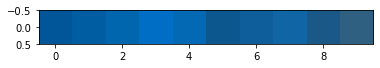

```python
index_list = [0, 50, 300, 500, 800, 1600, 1800, 2000, 2500, 3000]
blues_rgb = []

for i in index_list:
    r, g, b = unique_colour_list[i]
    blues_rgb.append((r, g, b))

print(blues_rgb)
plt.imshow([blues_rgb])
```

Which blue should we pick? This is harder than expected!

```python
# list of all colours (pixels) in our image
full_colour_list = image.reshape(-1, image.shape[2]).tolist()
```

```python
# three most commonly occuring colours
from collections import Counter
counts = Counter([tuple(sublist) for sublist in full_colour_list])
most_common_colours = counts.most_common()[:3]
most_common_colours
```

```
[((255, 255, 255), 117299), ((239, 50, 56), 63185), ((3, 100, 169), 30324)]
```

```python
common_colours = []
for i in range(0, len(most_common_colours)):
    common_colours.append(most_common_colours[i][0])

common_colours
```

```
[(255, 255, 255), (239, 50, 56), (3, 100, 169)]
```

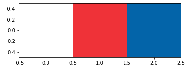

```python
plt.imshow([common_colours])
```

Great! I guess these would work... but since we already fired up our jupyter notebook, let's quickly try another approach to finding the three dominant colours in our image, k-means clustering.

```python
# converting our image matrix to three individual lists containing the respective red, blue and green values
r = []
g = []
b = []

for line in image:

    # looping through each pixel of our image
    for pixel in line:
        temp_r, temp_g, temp_b = pixel

        # appending the RGB values to our r, g and b lists
        r.append(temp_r)
        g.append(temp_g)
        b.append(temp_b)
```

```python
# convert the r, g, b lists to columns in a pandas dataframe
df = pd.DataFrame({'red': r, 'green': g, 'blue': b,})
```

```python
df
```

|  | red | green | blue |
| --- | --- | --- | --- |
| 0 | 255 | 255 | 255 |
| 1 | 255 | 255 | 255 |
| 2 | 255 | 255 | 255 |
| 3 | 255 | 255 | 255 |
| 4 | 255 | 255 | 255 |
| ... | ... | ... | ... |
| 279615 | 255 | 255 | 255 |
| 279616 | 255 | 255 | 255 |
| 279617 | 255 | 255 | 255 |
| 279618 | 255 | 255 | 255 |
| 279619 | 255 | 255 | 255 |

279620 rows × 3 columns

We will use SciPy for our k-means clustering.

Step 1: Standardise the variables by dividing each data point by its standard deviation to ensure that the variations in each variable affect the clusters equally.

```python
# standardising our r, g and b values using the whiten() function
from scipy.cluster.vq import whiten

df['scaled_red'] = whiten(df['red'])
df['scaled_green'] = whiten(df['green'])
df['scaled_blue'] = whiten(df['blue'])

df.sample(10)
```

|  | red | green | blue | scaled_red | scaled_green | scaled_blue |
| --- | --- | --- | --- | --- | --- | --- |
| 277409 | 255 | 255 | 255 | 2.675008 | 2.757168 | 3.045270 |
| 111094 | 239 | 50 | 56 | 2.507165 | 0.540621 | 0.668765 |
| 34388 | 239 | 50 | 56 | 2.507165 | 0.540621 | 0.668765 |
| 273201 | 255 | 255 | 255 | 2.675008 | 2.757168 | 3.045270 |
| 7513 | 249 | 255 | 255 | 2.612067 | 2.757168 | 3.045270 |
| 48844 | 239 | 50 | 56 | 2.507165 | 0.540621 | 0.668765 |
| 166716 | 3 | 100 | 169 | 0.031471 | 1.081242 | 2.018238 |
| 222597 | 255 | 255 | 255 | 2.675008 | 2.757168 | 3.045270 |
| 241387 | 204 | 254 | 255 | 2.140007 | 2.746355 | 3.045270 |
| 104421 | 235 | 47 | 61 | 2.465204 | 0.508184 | 0.728476 |

Step 2: Perform k-means clustering with the standardised columns.

```python
from scipy.cluster.vq import kmeans
cluster_centers, distortion = kmeans(df[['scaled_red', 'scaled_green', 'scaled_blue']], 3)
```

Our dominant colours are represented by our cluster centers.

```python
cluster_centers
```

```
array([[0.06244753, 1.09026902, 2.01476764],
       [2.65925476, 2.74729736, 3.03389857],
       [2.5039984 , 0.54568642, 0.67451551]])
```

The results we get are standardised versions of rgb values. To get the original colour values, we need to multiply them with their standard deviations.

```python
kmeans_colours = []

r_std, g_std, b_std = df[['red', 'green', 'blue']].std()

for cluster_center in cluster_centers:
    scaled_r, scaled_g, scaled_b = cluster_center

    kmeans_colours.append((round(scaled_r * r_std),
                           round(scaled_g * g_std),
                           round(scaled_b * b_std)))

kmeans_colours
```

```
[(6, 101, 169), (253, 254, 254), (239, 50, 56)]
```

[figure not shown]

```python
plt.imshow([kmeans_colours])
```

Great, let's compare our results: common colours vs k-means clustering!

```python
# function to isolate the blue values from our list of colours
# (this function may need to be adjusted for logos using different colour schemes...)
def get_blue(list_of_colours):
    for colour in list_of_colours:
        r, g, b = colour
        if r <= 50:
            blue_rgb = (r, g, b)
    return blue_rgb
```

```python
blue_common_colours = get_blue(common_colours)
blue_common_colours
```

```
(3, 100, 169)
```

```python
blue_kmeans = get_blue(kmeans_colours)
blue_kmeans
```

```
(6, 101, 169)
```

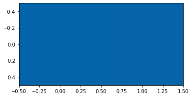

```python
blues = [blue_common_colours, blue_kmeans]
plt.imshow([blues])
```

Visually the colours are not (or barely) distinguishable! I think they would both look fantastic on a Pepsi resume...

As a side note for our clustering results, it is possible that the colours we end up with don't actually exist within the original image, given they are just the RGB value that are at the centre of our clusters. Let's see if the blue we ended up with exists in our original image.

```python
blue_kmeans_r, blue_kmeans_g, blue_kmeans_b  = blue_kmeans
```

```python
# checking if our colour exists in the image
df[(df['red'] == blue_kmeans_r) & (df['green'] == blue_kmeans_g) & (df['blue'] == blue_kmeans_b)]
```

|  | red | green | blue | scaled_red | scaled_green | scaled_blue |
| --- | --- | --- | --- | --- | --- | --- |
| 108171 | 6 | 101 | 169 | 0.062941 | 1.092055 | 2.018238 |
| 111378 | 6 | 101 | 169 | 0.062941 | 1.092055 | 2.018238 |
| 132008 | 6 | 101 | 169 | 0.062941 | 1.092055 | 2.018238 |
| 132908 | 6 | 101 | 169 | 0.062941 | 1.092055 | 2.018238 |
| 136504 | 6 | 101 | 169 | 0.062941 | 1.092055 | 2.018238 |
| 140082 | 6 | 101 | 169 | 0.062941 | 1.092055 | 2.018238 |
| 144985 | 6 | 101 | 169 | 0.062941 | 1.092055 | 2.018238 |
| 149682 | 6 | 101 | 169 | 0.062941 | 1.092055 | 2.018238 |
| 156432 | 6 | 101 | 169 | 0.062941 | 1.092055 | 2.018238 |
| 160627 | 6 | 101 | 169 | 0.062941 | 1.092055 | 2.018238 |
| 180966 | 6 | 101 | 169 | 0.062941 | 1.092055 | 2.018238 |
| 188217 | 6 | 101 | 169 | 0.062941 | 1.092055 | 2.018238 |
| 191952 | 6 | 101 | 169 | 0.062941 | 1.092055 | 2.018238 |
| 224541 | 6 | 101 | 169 | 0.062941 | 1.092055 | 2.018238 |
| 234147 | 6 | 101 | 169 | 0.062941 | 1.092055 | 2.018238 |
| 234160 | 6 | 101 | 169 | 0.062941 | 1.092055 | 2.018238 |
| 234161 | 6 | 101 | 169 | 0.062941 | 1.092055 | 2.018238 |
| 234236 | 6 | 101 | 169 | 0.062941 | 1.092055 | 2.018238 |
| 236222 | 6 | 101 | 169 | 0.062941 | 1.092055 | 2.018238 |
| 236223 | 6 | 101 | 169 | 0.062941 | 1.092055 | 2.018238 |
| 238485 | 6 | 101 | 169 | 0.062941 | 1.092055 | 2.018238 |
| 241966 | 6 | 101 | 169 | 0.062941 | 1.092055 | 2.018238 |
| 249295 | 6 | 101 | 169 | 0.062941 | 1.092055 | 2.018238 |
| 256728 | 6 | 101 | 169 | 0.062941 | 1.092055 | 2.018238 |
| 257804 | 6 | 101 | 169 | 0.062941 | 1.092055 | 2.018238 |
| 258087 | 6 | 101 | 169 | 0.062941 | 1.092055 | 2.018238 |
| 261000 | 6 | 101 | 169 | 0.062941 | 1.092055 | 2.018238 |
| 262191 | 6 | 101 | 169 | 0.062941 | 1.092055 | 2.018238 |
| 262581 | 6 | 101 | 169 | 0.062941 | 1.092055 | 2.018238 |
| 263467 | 6 | 101 | 169 | 0.062941 | 1.092055 | 2.018238 |
| 264453 | 6 | 101 | 169 | 0.062941 | 1.092055 | 2.018238 |

Now we just need to update our resume with the correspoding colour theme. To be able to do so, we might need to convert our results to hex values as some document editors only allow us to specify hex, not rgb.

```python
# function to convert rgb to hex
def rgb_to_hex(r, g, b):
    return ('{:X}{:X}{:X}').format(r, g, b)
```

```python
blue_common_r, blue_common_g, blue_common_b = blue_common_colours
print(rgb_to_hex(blue_common_r, blue_common_g, blue_common_b))
```

```
364A9
```

```python
print(rgb_to_hex(blue_kmeans_r, blue_kmeans_g, blue_kmeans_b))
```

```
665A9
```

```python
# our results need to be updated so we get the full hex codes
common_hex = '#0' + rgb_to_hex(blue_common_r, blue_common_g, blue_common_b)
kmeans_hex = '#0' + rgb_to_hex(blue_kmeans_r, blue_kmeans_g, blue_kmeans_b)
print(common_hex, kmeans_hex)
```

```
#0364A9 #0665A9
```